# Median Negative & Positive Affect in Daily Life During COVID-19 ~ Number of Close Friends * Number of Stressors

Ovidia Stanoi

2025-02-10

### Prepare data for regression analyses.

Remove all data from the global environment.

```r
remove(list=ls())
```

Load libraries.

```r
library("tidyverse")
library("rstanarm")
library("sjPlot")
library("brms")
library("ggpubr")
```

Set up ggplot theme.

```r
theme_set(theme_bw() +
            theme(plot.title = element_text(size=14, hjust = .5),
                  axis.text=element_text(size=12),
                  axis.title=element_text(size=13),
                  strip.text = element_text(size=12),
                  # plot.title = element_text(size=20, hjust = .5), # use this for .pdf version of figures instead of .html
                  # axis.text=element_text(size=20),  # use this for .pdf version of figures instead of .html
                  # axis.title=element_text(size=22), # use this for .pdf version of figures instead of .html
                  # strip.text = element_text(size=18), # use this for .pdf version of figures instead of .html
                  axis.line = element_line(colour = "gray"),
                  panel.border = element_rect(colour = "gray"),
                  panel.grid.minor = element_blank(),
                  panel.background = element_rect(colour = "gray", linewidth = .8),
                  strip.background.x = element_rect(fill = "white", linetype = "solid",
                                          color = "gray", linewidth = .8),
                  legend.position = "none"))
```

Specify your directory path below.

```r
path <- ""
```

Open dataset.

```r
covid_ema <- read.csv(sprintf("%s/Data/all_data_merged_clean.csv", path))
```

See the distribution of the two outcome variables: positive and negative affect.

##### Negative Affect

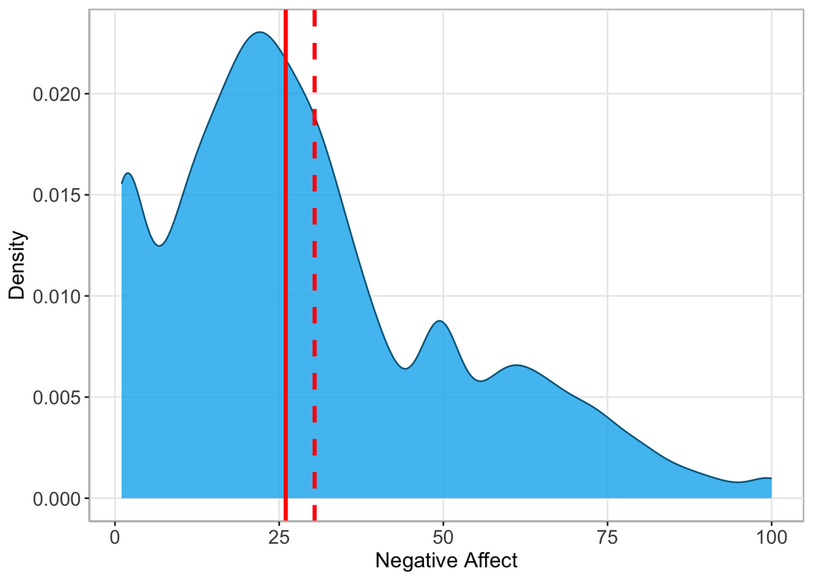

```r
ggplot(covid_ema, aes(NegativeMood)) +
  geom_density(fill = "deepskyblue2", color = "deepskyblue4", alpha = .8) +
  labs(x = "Negative Affect",
       y = "Density") +
  geom_vline(xintercept = median(covid_ema$NegativeMood, na.rm = T),
             color = "red", linewidth = 1.2) +
  geom_vline(xintercept = mean(covid_ema$NegativeMood, na.rm = T),
             color = "red", linewidth = 1.2, linetype = "dashed")
```

##### Positive Affect

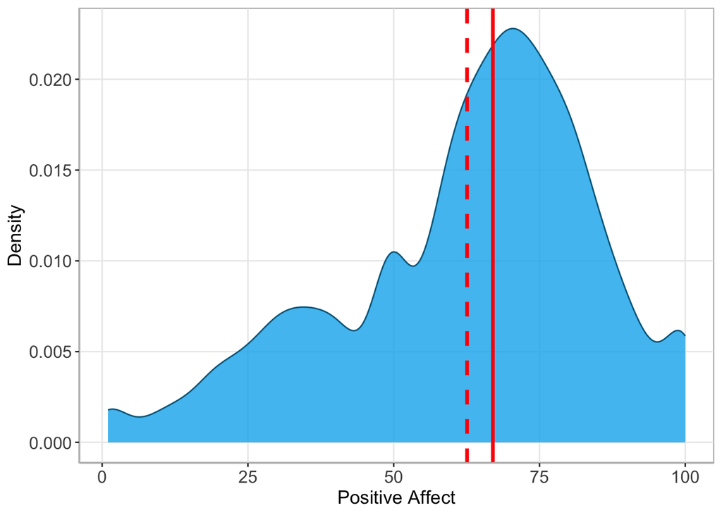

```r
ggplot(covid_ema, aes(PositiveMood)) +
  geom_density(fill = "deepskyblue2", color = "deepskyblue4", alpha = .8) +
  labs(x = "Positive Affect",
       y = "Density") +
  geom_vline(xintercept = median(covid_ema$PositiveMood, na.rm = T),
             color = "red", linewidth = 1.2) +
  geom_vline(xintercept = mean(covid_ema$PositiveMood, na.rm = T),
             color = "red", linewidth = 1.2, linetype = "dashed")
```

Run Kolmogorov-Smirnov test to check whether the negative affect variable is normally distributed.

```r
t_neg <- ks.test(covid_ema$NegativeMood, "pnorm")
t_neg
```

```
##
##  Asymptotic one-sample Kolmogorov-Smirnov test
##
## data:  covid_ema$NegativeMood
## D = 0.90131, p-value < 2.2e-16
## alternative hypothesis: two-sided
```

Run Kolmogorov-Smirnov test to check whether the positive affect variable is normally distributed.

```r
t_pos <- ks.test(covid_ema$PositiveMood, "pnorm")
t_pos
```

```
##
##  Asymptotic one-sample Kolmogorov-Smirnov test
##
## data:  covid_ema$PositiveMood
## D = 0.98772, p-value < 2.2e-16
## alternative hypothesis: two-sided
```

Extract for each participant their median negative and positive affect in the EMA period, as well as their number of close friend prior to the COVID-19 pandemic, their baseline demographic information, COVID-19 living conditions, number of stressors, and EMA completion rates. All these variables will be added in the regression model.

```r
df <- covid_ema %>%
  group_by(pID) %>%
  dplyr::summarise(groupID = unique(groupID),
            median_NegativeMood = median(NegativeMood, na.rm = T),
            median_PositiveMood = median(PositiveMood, na.rm = T),
            baseline_closest_deg_out_norm = unique(baseline_closest_deg_out_norm),
            covid_stress_self_nr = unique(covid_stress_self_nr),
            baseline_income_num = unique(baseline_income_num),
            baseline_educ_parents_years = unique(baseline_educ_parents_years),
            baseline_college_year = unique(baseline_college_year),
            baseline_gender_numeric = unique(baseline_gender_numeric),
            covid_housing_tension = unique(covid_housing_tension),
            covid_phys_dist = unique(covid_phys_dist_avg),
            EMA_completion_rate = unique(EMA_completion_rate))
```

Center continuous predictors around the sample mean and binary variables around zero.

```r
df$baseline_closest_deg_out_norm_c <- df$baseline_closest_deg_out_norm - mean(df$baseline_closest_deg_out_norm, na.rm = T)
df$covid_stress_self_nr_c <- df$covid_stress_self_nr - mean(df$covid_stress_self_nr, na.rm = T)
df$baseline_income_num_c <- df$baseline_income_num - mean(df$baseline_income_num, na.rm = T)
df$baseline_educ_parents_years_c <- df$baseline_educ_parents_years - mean(df$baseline_educ_parents_years, na.rm = T)
df$baseline_college_year_c <- df$baseline_college_year - mean(df$baseline_college_year, na.rm = T)
df$baseline_gender_numeric_c <- df$baseline_gender_numeric - .5
df$covid_housing_tension_c <- df$covid_housing_tension - mean(df$covid_housing_tension, na.rm = T)
df$covid_phys_dist_c  <- df$covid_phys_dist - mean(df$covid_phys_dist, na.rm = T)
df$EMA_completion_rate_c  <- df$EMA_completion_rate - mean(df$EMA_completion_rate, na.rm = T)
```

Show the distribution of the number of close friends variable.

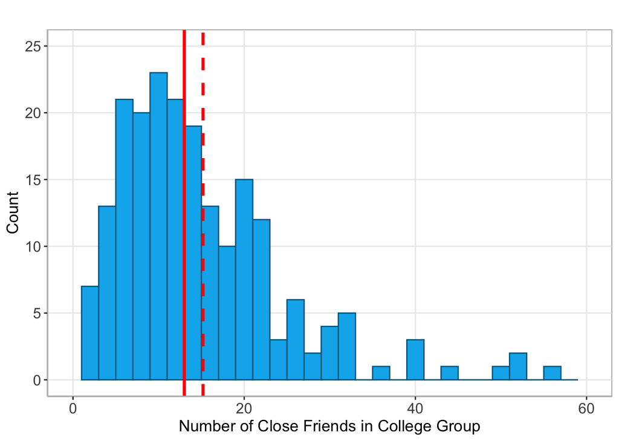

```r
ggplot(df, aes(baseline_closest_deg_out_norm)) +
  geom_histogram(fill = "deepskyblue2", color = "deepskyblue4", binwidth = 2) +
  labs(x = "Number of Close Friends in College Group",
       y = "Count",
       title = "") +
  geom_vline(xintercept = median(df$baseline_closest_deg_out_norm, na.rm = T),
             color = "red", linewidth = 1.2) +
  geom_vline(xintercept = mean(df$baseline_closest_deg_out_norm, na.rm = T),
             color = "red", linewidth = 1.2, linetype = "dashed") +
  lims(x = c(0,60), y = c(0, 25))
```

### Run regression models

##### Model 1: Outcome Variable = Negative Affect

**RQ**: Do close friendships in college buffer against the negative impact of COVID-19-related stressors on negative affect?

Run regression analysis 1: median negative affect ~ number of close friends * number of COVID-19 stressors.

```r
# options(mc.cores = parallel::detectCores())
# f1 <- stan_glmer(median_NegativeMood ~ baseline_closest_deg_out_norm_c * covid_stress_self_nr_c +
#                    baseline_college_year_c + baseline_gender_numeric_c +
#                    baseline_income_num_c + baseline_educ_parents_years_c +
#                    covid_housing_tension_c + covid_phys_dist_c +
#                    EMA_completion_rate_c + (1 | groupID),
#                   data = df, seed = 123)
# save(f1, file = sprintf("%s/Models/1. Median-NegAff_Out-Degree_Self-Stressors.RData", path))
```

##### Model 2: Outcome Variable = Positive Affect

**RQ**: Do close friendships in college buffer against the negative impact of COVID-19-related stressors on positive affect?

Run regression analysis 2: median positive affect ~ number of close friends * number of COVID-19 stressors.

```r
# options(mc.cores = parallel::detectCores())
# f2 <- stan_glmer(median_PositiveMood ~ baseline_closest_deg_out_norm_c * covid_stress_self_nr_c +
#                    baseline_college_year_c + baseline_gender_numeric_c +
#                    baseline_income_num_c + baseline_educ_parents_years_c +
#                    covid_housing_tension_c + covid_phys_dist_c +
#                    EMA_completion_rate_c + (1 | groupID),
#                   data = df, seed = 123)
# save(f2, file = sprintf("%s/Models/1. Median-PosAff_Out-Degree_Self-Stressors.RData", path))
```

### Summarize results

Create a table that presents the parameter estimates from the two models together.

```r
load(sprintf("%s/Models/1. Median-NegAff_Out-Degree_Self-Stressors.RData", path))
load(sprintf("%s/Models/1. Median-PosAff_Out-Degree_Self-Stressors.RData", path))
tab_model(f1, f2, show.se = TRUE,
          show.r2 = TRUE,
          dv.labels = c("Median Negative Affect",
                        "Median Positive Affect "),
          pred.labels = c("(Intercept)",
                          "Number Friends Prior to COVID-19",
                          "Number of COVID-19-related Stressors",
                          "Year in College",
                          "Female",
                          "HH Income",
                          "Parents' Education",
                          "HH Tension",
                          "Physical Distance",
                          "EMA Completion Rate",
                          "Number Friends * Number of Stressors Interaction"))
```

|  | Median Negative Affect |  |  | Median Positive Affect |  |  |
| --- | --- | --- | --- | --- | --- | --- |
| Predictors | Estimates | std. Error | CI (95%) | Estimates | std. Error | CI (95%) |
| (Intercept) | 26.93 | 1.32 | 24.26 – 29.64 | 65.05 | 1.34 | 62.36 – 67.75 |
| Number Friends Prior to COVID-19 | -0.31 | 0.11 | -0.51 – -0.10 | 0.29 | 0.12 | 0.06 – 0.52 |
| Number of COVID-19-related Stressors | 0.73 | 0.41 | -0.09 – 1.53 | -0.90 | 0.42 | -1.75 – -0.04 |
| Year in College | -2.15 | 0.92 | -3.86 – -0.38 | 1.80 | 0.96 | -0.04 – 3.62 |
| Female | -1.06 | 2.50 | -6.03 – 3.91 | -1.66 | 2.66 | -6.86 – 3.55 |
| HH Income | -0.00 | 0.20 | -0.40 – 0.39 | -0.04 | 0.22 | -0.49 – 0.38 |
| Parents’ Education | -0.21 | 0.27 | -0.72 – 0.30 | 0.22 | 0.30 | -0.36 – 0.80 |
| HH Tension | 0.07 | 0.04 | -0.01 – 0.15 | -0.05 | 0.04 | -0.14 – 0.03 |
| Physical Distance | -0.10 | 1.48 | -3.03 – 2.75 | -0.79 | 1.59 | -3.91 – 2.33 |
| EMA Completion Rate | -10.37 | 7.78 | -24.94 – 4.45 | 17.89 | 8.05 | 2.16 – 34.08 |
| Number Friends * Number of Stressors Interaction | -0.07 | 0.04 | -0.14 – 0.00 | 0.06 | 0.04 | -0.02 – 0.14 |
| Random Effects |  |  |  |  |  |  |
| σ<sup>2</sup> | 198.98 |  |  | 232.01 |  |  |
| τ<sub>00</sub> | 8.80 <sub>groupID</sub> |  |  | 6.00 <sub>groupID</sub> |  |  |
| ICC | 0.04 |  |  | 0.03 |  |  |
| N | 24 <sub>groupID</sub> |  |  | 24 <sub>groupID</sub> |  |  |
| Observations | 205 |  |  | 205 |  |  |
| Marginal R<sup>2</sup> / Conditional R<sup>2</sup> | 0.107 / 0.145 |  |  | 0.104 / 0.126 |  |  |

Below, extract the proportion of the posterior distribution that is above or below zero for each predictor of interest separately for the two regression model (negative and positive affect outcome variables).

##### Model 1: Outcome Variable = Negative Affect

Extract the posterior distributions of the parameter estimates from the first regression model.

```r
posterior <- as.data.frame(as.matrix(f1))
```

Extract the number of individual points included in a posterior distribution.

```r
n <- length(posterior$baseline_closest_deg_out_norm_c)
n
```

```
## [1] 4000
```

Calculate the proportion of the posterior distribution that is lower than 0 for the main effect of the number of close friends on median negative affect.

```r
round(length(which(posterior$baseline_closest_deg_out_norm_c < 0))/n*100,1)
```

```
## [1] 99.8
```

Calculate the proportion of the posterior distribution that is higher than 0 for the main effect of number of stressors on median negative affect.

```r
round(length(which(posterior$covid_stress_self_nr_c > 0))/n*100,1)
```

```
## [1] 96.1
```

Calculate the proportion of the posterior distribution that is lower than 0 for the interaction effect between participants’ number of close friends and their number of stressors on median negative affect.

```r
round(length(which(posterior$`baseline_closest_deg_out_norm_c:covid_stress_self_nr_c` < 0))/n*100,1)
```

```
## [1] 97.3
```

Calculate the total $R^2$ for the model.

```r
round(mean(bayes_R2(f1)),2)
```

```
## [1] 0.17
```

##### Model 2: Outcome Variable = Positive Affect

```r
posterior <- as.data.frame(as.matrix(f2))
```

Extract the number of individual points included in a posterior distribution.

```r
n <- length(posterior$baseline_closest_deg_out_norm_c)
n
```

```
## [1] 4000
```

Calculate the proportion of the posterior distribution that is higher than 0 for the main effect of the number of close friends on median positive affect.

```r
round(length(which(posterior$baseline_closest_deg_out_norm_c > 0))/n*100,1)
```

```
## [1] 99.4
```

Calculate the proportion of the posterior distribution that is lower than 0 for the main effect of number of stressors on median positive affect.

```r
round(length(which(posterior$covid_stress_self_nr_c < 0))/n*100,1)
```

```
## [1] 97.8
```

Calculate the proportion of the posterior distribution that is higher than 0 for the interaction effect between participants’ number of close friends and their number of stressors on median positive affect.

```r
round(length(which(posterior$`baseline_closest_deg_out_norm_c:covid_stress_self_nr_c` > 0))/n*100,1)
```

```
## [1] 93.7
```

Calculate the total $R^2$ for the model.

```r
round(mean(bayes_R2(f2)),2)
```

```
## [1] 0.15
```

### General Linear Hypothesis Tests (GLHT)

##### Model 1: Outcome Variable = Negative Affect

Test the hypothesis: does the slope representing the relationship between participants’ number of stressors and median negative affect differ from zero for 1) students with few friends at school (1.5 SD below mean), 2) students with many friends at school (1.5 SD above mean)?

```r
# Calculate mean number of close friends  +/-1.5SD
lw_1.5sd <- round(-1.5*sd(df$baseline_closest_deg_out_norm_c, na.rm = T),3)
lw_1.5sd
```

```
## [1] -14.884
```

```r
up_1.5sd <- round(+1.5*sd(df$baseline_closest_deg_out_norm_c, na.rm = T),3)
up_1.5sd
```

```
## [1] 14.884
```

```r
# Define the number of draws from the posterior distribution
n <- 4000
```

Test the hypothesis for those with few close friends first.

```r
my_hyp_lw <- hypothesis(f1, "1*covid_stress_self_nr_c +
                      -14.884*baseline_closest_deg_out_norm_c:covid_stress_self_nr_c = 0")
p <- my_hyp_lw$samples
df_hyp <- my_hyp_lw$hypothesis[ ,2:5] %>%
  mutate(Prop.Above.Zero = length(which(p$H1 > 0))/n) %>%
  mutate_if(is.numeric, funs(round(., digits = 2)))
df_hyp
```

```
##   Estimate Est.Error CI.Lower CI.Upper Prop.Above.Zero
## 1     1.79      0.74     0.31     3.24            0.99
```

Test the hypothesis for those with many close friends.

```r
my_hyp_up <- hypothesis(f1, "1*covid_stress_self_nr_c +
                      +14.884*baseline_closest_deg_out_norm_c:covid_stress_self_nr_c = 0")
p <- my_hyp_up$samples
df_hyp <- my_hyp_up$hypothesis[ ,2:5] %>%
  mutate(Prop.Above.Zero = length(which(p$H1 > 0))/n) %>%
  mutate_if(is.numeric, funs(round(., digits = 2)))
df_hyp
```

```
##   Estimate Est.Error CI.Lower CI.Upper Prop.Above.Zero
## 1    -0.35      0.62    -1.57     0.86            0.29
```

##### Model 2: Outcome Variable = Positive Affect

Test the hypothesis: does the slope representing the relationship between between participants’ number of stressors and median positive affect differ from zero for 1) students without many friends at school (-1.5 SD), 2) students with many friends at school (+1.5 SD)?

Test the hypothesis for those with few close friends first.

```r
my_hyp_lw <- hypothesis(f2, "1*covid_stress_self_nr_c +
                      -14.884*baseline_closest_deg_out_norm_c:covid_stress_self_nr_c = 0")
p <- my_hyp_lw$samples
df_hyp <- my_hyp_lw$hypothesis[ ,2:5] %>%
  mutate(Prop.Below.Zero = length(which(p$H1 < 0))/n) %>%
  mutate_if(is.numeric, funs(round(., digits = 2)))
df_hyp
```

```
##   Estimate Est.Error CI.Lower CI.Upper Prop.Below.Zero
## 1    -1.84      0.81    -3.43     -0.3            0.99
```

Test the hypothesis for those with many close friends next.

```r
my_hyp_up <- hypothesis(f2, "1*covid_stress_self_nr_c +
                      +14.884*baseline_closest_deg_out_norm_c:covid_stress_self_nr_c = 0")
p <- my_hyp_up$samples
df_hyp <- my_hyp_up$hypothesis[ ,2:5] %>%
  mutate(Prop.Below.Zero = length(which(p$H1 < 0))/n) %>%
  mutate_if(is.numeric, funs(round(., digits = 2)))
df_hyp
```

```
##   Estimate Est.Error CI.Lower CI.Upper Prop.Below.Zero
## 1     0.04      0.69     -1.3     1.37            0.48
```

### Plot results

##### Model 1: Outcome Variable = Negative Affect

Create a scatterplot showing the relationship between the number of stressors experienced by participants and their median negative affect in daily life separately for those with few friends and those with many friends.

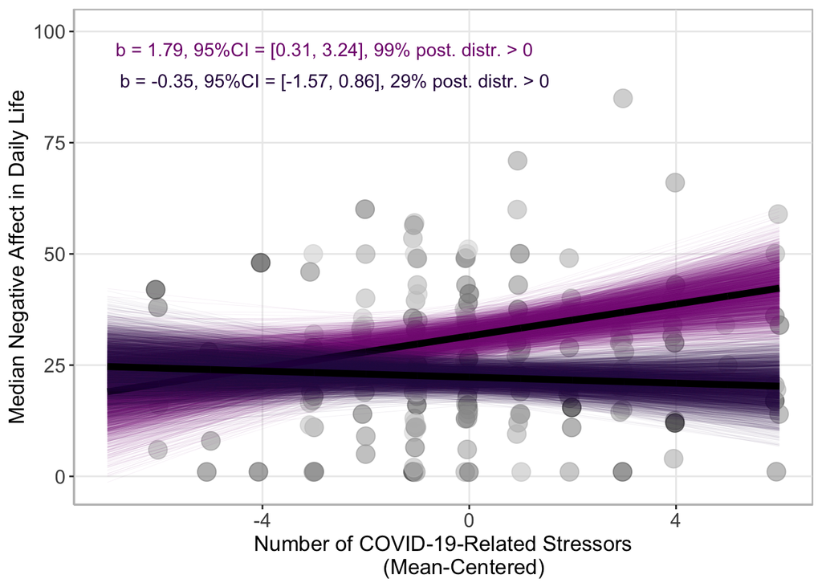

```r
# Extract all posterior distributions
p <- posterior_samples(f1)[, c(1:3,11)]
colnames(p) <- c("intercept", "b_close_outdeg", "b_nr_covid_stressors", "b_close_outdeg_nr_covid_stressors_int")

# Extract fixed effects medians from the model
p <- p %>%
  dplyr::mutate(draw = 1:n,
                m_int = median(intercept),
                m_b_close_outdeg = median(b_close_outdeg),
                m_b_nr_covid_stressors = median(b_nr_covid_stressors),
                m_b_close_outdeg_nr_covid_stressors_int = median(b_close_outdeg_nr_covid_stressors_int))

# Define the number of posterior draws
nr_random_draws <- 4000

# Create a dataframe that includes predicted y values for each draw when the participant has few friends
p_lw <- p[rep(seq_len(nrow(p)), each = 14), ] %>%
  dplyr::mutate(seq = rep(-7:6, nr_random_draws),
                close_out_deg = lw_1.5sd,
                close_out_deg_label = "Low Close Out-Deg (-1.5 SD)") %>%
  rowwise() %>%
  dplyr::mutate(y_draw = intercept + b_close_outdeg * close_out_deg +  b_nr_covid_stressors * seq +
                  b_close_outdeg_nr_covid_stressors_int * close_out_deg * seq,
                y_fe = m_int + m_b_close_outdeg * close_out_deg + m_b_nr_covid_stressors * seq +
                  m_b_close_outdeg_nr_covid_stressors_int * close_out_deg * seq)

# Create a dataframe that includes predicted y values for each draw when the participant has many friends
p_up <- p[rep(seq_len(nrow(p)), each = 14), ] %>%
  mutate(seq = rep(-7:6, nr_random_draws),
         close_out_deg = up_1.5sd,
         close_out_deg_label = "High Close Out-Deg (+ 1.5 SD)") %>%
  rowwise() %>%
  dplyr::mutate(y_draw = intercept + b_close_outdeg * close_out_deg +  b_nr_covid_stressors * seq +
                  b_close_outdeg_nr_covid_stressors_int * close_out_deg * seq,
                y_fe = m_int + m_b_close_outdeg * close_out_deg + m_b_nr_covid_stressors * seq +
                  m_b_close_outdeg_nr_covid_stressors_int * close_out_deg * seq)

# Merge files
p_all <- rbind(p_lw, p_up)

## Plot results -- together in one graph
g0 <- ggplot(data = df, aes(covid_stress_self_nr_c, median_NegativeMood)) +
  geom_jitter(aes(color = baseline_closest_deg_out_norm_c),
              alpha = .6, width = .05, height = .05, size = 5) +
  scale_color_gradient(low="gray90", high="gray10", guide = "none") +
  expand_limits(y=c(0, 100)) +
  scale_y_continuous(breaks = c(0,25,50,75,100)) +
  labs(x = "Number of COVID-19-Related Stressors
       (Mean-Centered)",
       y = "Median Negative Affect in Daily Life")

g1 <- g0 + geom_line(data = p_lw, aes(x = seq, y= y_draw,
                                      group = draw),
                     color = "#810F7C",
                     alpha = .1, size = .1) +
  geom_line(data = p_lw, aes(x = seq, y = y_fe),
            color = "black", size = 2)

g2 <- g1 +
  geom_line(data = p_up, aes(x = seq, y= y_draw,
                             group = draw),
            color = "#2D004B",
            alpha = .1, size = .1) +
  geom_line(data = p_up, aes(x = seq,
                             y = y_fe),
            color = "black", size = 2)

g3 <- g2 +
  annotate(geom="text", x=-2.8, y=96, size = 4, color="#810F7C",
           label="b = 1.79, 95%CI = [0.31, 3.24], 99% post. distr. > 0") +
   annotate(geom="text", x=-2.6, y=89, size = 4, color="#2D004B",
           label="b = -0.35, 95%CI = [-1.57, 0.86], 29% post. distr. > 0")
g3
```

##### Model 2: Outcome Variable = Positive Affect

Create a scatterplot showing the relationship between the number of stressors experienced by participants and their median positive affect in daily life separately for those with few friends and those with many friends.

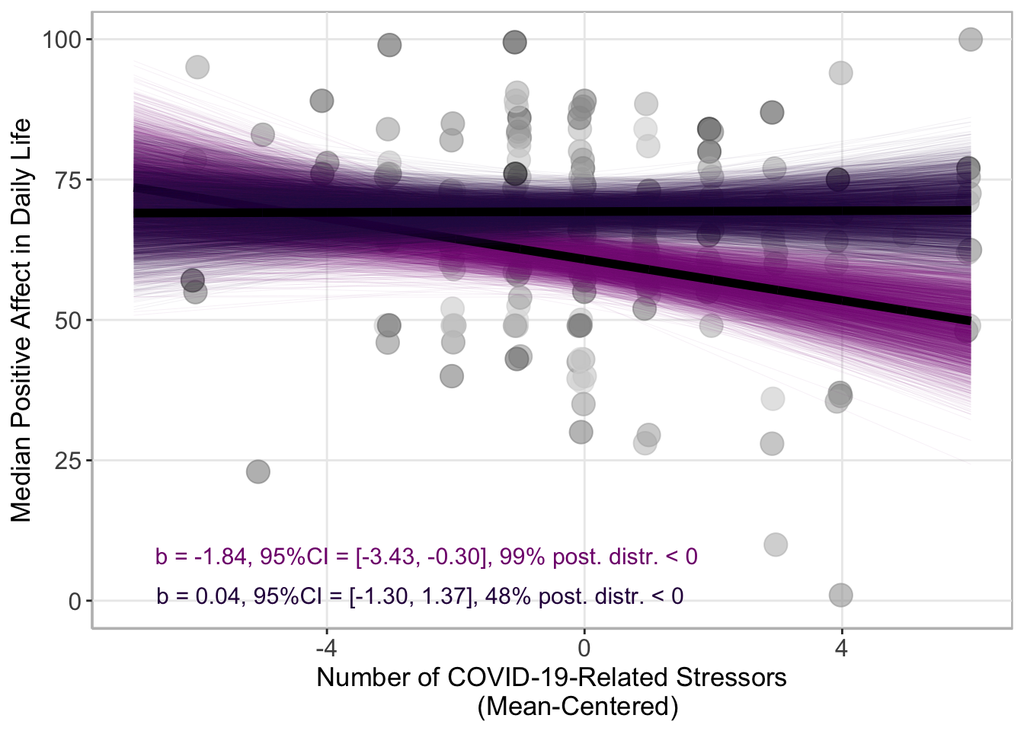

```r
# Extract all posterior distributions
p <- posterior_samples(f2)[, c(1:3,11)]
colnames(p) <- c("intercept", "b_close_outdeg", "b_nr_covid_stressors", "b_close_outdeg_nr_covid_stressors_int")

# Extract fixed effects medians from the model
p <- p %>%
  dplyr::mutate(draw = 1:n,
                m_int = median(intercept),
                m_b_close_outdeg = median(b_close_outdeg),
                m_b_nr_covid_stressors = median(b_nr_covid_stressors),
                m_b_close_outdeg_nr_covid_stressors_int = median(b_close_outdeg_nr_covid_stressors_int))

# Define the number of posterior draws
nr_random_draws <- 4000

# Create a dataframe that includes predicted y values for each draw when the participant has few friends
p_lw <- p[rep(seq_len(nrow(p)), each = 14), ] %>%
  dplyr::mutate(seq = rep(-7:6, nr_random_draws),
                close_out_deg = lw_1.5sd,
                close_out_deg_label = "Low Close Out-Deg (-1.5 SD)") %>%
  rowwise() %>%
  dplyr::mutate(y_draw = intercept + b_close_outdeg * close_out_deg +  b_nr_covid_stressors * seq +
                  b_close_outdeg_nr_covid_stressors_int * close_out_deg * seq,
                y_fe = m_int + m_b_close_outdeg * close_out_deg + m_b_nr_covid_stressors * seq +
                  m_b_close_outdeg_nr_covid_stressors_int * close_out_deg * seq)

# Create a dataframe that includes predicted y values for each draw when the participant has many friends
p_up <- p[rep(seq_len(nrow(p)), each = 14), ] %>%
  mutate(seq = rep(-7:6, nr_random_draws),
         close_out_deg = up_1.5sd,
         close_out_deg_label = "High Close Out-Deg (+ 1.5 SD)") %>%
  rowwise() %>%
  dplyr::mutate(y_draw = intercept + b_close_outdeg * close_out_deg +  b_nr_covid_stressors * seq +
                  b_close_outdeg_nr_covid_stressors_int * close_out_deg * seq,
                y_fe = m_int + m_b_close_outdeg * close_out_deg + m_b_nr_covid_stressors * seq +
                  m_b_close_outdeg_nr_covid_stressors_int * close_out_deg * seq)

# Merge files
p_all <- rbind(p_lw, p_up)

## Plot results -- together in one graph
g0 <- ggplot(data = df, aes(covid_stress_self_nr_c, median_PositiveMood)) +
  geom_jitter(aes(color = baseline_closest_deg_out_norm_c),
              alpha = .6, width = .05, height = .05, size = 5) +
  scale_color_gradient(low="gray90", high="gray10", guide = "none") +
  expand_limits(y=c(0, 100)) +
  labs(x = "Number of COVID-19-Related Stressors
       (Mean-Centered)",
       y = "Median Positive Affect in Daily Life")

g1 <- g0 + geom_line(data = p_lw, aes(x = seq, y= y_draw,
                                      group = draw),
                     color = "#810F7C",
                     alpha = .1, size = .1) +
  geom_line(data = p_lw, aes(x = seq, y = y_fe),
            color = "black", size = 2)

g2 <- g1 +
  geom_line(data = p_up, aes(x = seq, y= y_draw,
                             group = draw),
            color = "#2D004B",
            alpha = .1, size = .1) +
  geom_line(data = p_up, aes(x = seq,
                             y = y_fe),
            color = "black", size = 2)

g3 <- g2 +
  annotate(geom="text", x = -2.45, y = 8, size = 4, color="#810F7C",
           label="b = -1.84, 95%CI = [-3.43, -0.30], 99% post. distr. < 0") +
    annotate(geom="text", x = -2.55, y = 1, size = 4, color="#2D004B",
           label="b = 0.04, 95%CI = [-1.30, 1.37], 48% post. distr. < 0")
g3
```